# Habitat-specific species from ANO

```r
library(sf)
library(tidyverse)
library(dplyr)
library(readxl)
library(forcats)
library(ggbreak)
library(vegan)
library(gridExtra)
library(writexl)
library(stringr)
library(patchwork)

Sys.setlocale(locale = "no_NB.utf8")

ANO.sp <- st_read(ano_gdb_path, layer = "ANO_Art", quiet = TRUE)
ANO.geo <- st_read(ano_gdb_path, layer="ANO_SurveyPoint", quiet = T)
```

# Cleaning

```r
# group under species to species
ANO.sp <- ANO.sp %>%
            mutate(art_navn = str_squish(art_navn),
              art_navn = if_else(str_count(art_navn, "\\S+") >= 3,
                word(art_navn, 1, 2),
                art_navn)) %>%
            group_by(parentglobalid, art_navn) %>%
            summarise(art_dekning   = sum(art_dekning, na.rm = TRUE),
                      art_norsk_navn = first(art_norsk_navn),
                      creator        = first(creator),
                      creationdate   = first(creationdate),
                      editor         = first(editor),
                      editdate       = first(editdate),
                      .groups = "drop")

# Some species are registeres but does not have cover,
ANO.sp <- ANO.sp %>%
           filter(art_dekning > 0)

# Clean up kartleggingsenhet and take out plots with missing data
ANO.geo1 <- ANO.geo %>%
              mutate(kartleggingsenhet_1m2 = str_extract(kartleggingsenhet_1m2, "^[A-Z0-9]+-[A-Z]+-[0-9]+"),
                     kartleggingsenhet_1m2 = na_if(kartleggingsenhet_1m2, "ikke_kartlagt"),
                     kartleggingsenhet_1m2 = na_if(kartleggingsenhet_1m2, "L")) %>%
              filter(!(is.na(kartleggingsenhet_1m2) | kartleggingsenhet_1m2 == ""))

# Fix variable names
ANO.geo1 <- ANO.geo1 %>%
              rename_with(.cols = starts_with("bv_"),
                          .fn = ~ toupper(str_remove(.x, "^bv_")))

ANO.geo1 <- ANO.geo1 %>%
                mutate(across('7GR_GI':'7SE', ~ {
                       ifelse( is.na(.x),
                                NA,
                                str_extract(.x, "(?<=_)[^_]+$"))
                      }))

df <- ANO.geo1 %>% st_drop_geometry()
vars <- names(df)[match("7GR_GI", names(df)) :
                  match("7SE", names(df))]
tables_list <- lapply(vars, function(v) {
                      table(df[[v]], useNA = "ifany")
                      })
names(tables_list) <- vars

tables_list
```

```
$`7GR_GI`

    1     2     3     4     5     X  <NA>
 2735    77    52    31    11     4 15181

$`7JB_BA`

    1     2     3     4     5     6     8     X  <NA>
 2692   669   185    49     2     3     4     8 14479

$`7JB_BT`

   1    2    3    4    5    6    X <NA>
8513 3984  711  105   56   50    6 4666

$`7JB_SI`

    1     2     3     4     6     X  <NA>
 2937     3     5     1     1   388 14756

$`7TK`

    0     1     2     3     X  <NA>
15366   368   238    64    14  2041

$`7SE`

   0    1    2    3    X <NA>
8951  210   36    3    3 8888
```

```r
# Add bioclimatic sones
temp <- st_read(sone_path, quiet = TRUE)

temp_df <- temp %>%
            st_drop_geometry() %>%
            select(SSBID, Sone_kode, Sone_navn)

ANO.geo2 <- ANO.geo1 %>%
                left_join(temp_df, by = c("ssb_id" = "SSBID")) %>%
                select(globalid, ssb_id, Sone_kode, Sone_navn, everything())
```

# Rescale and create tilstand variables

In the ANO system, the condition variables 7SE (spor etter slitasje) and 7TK (spor etter ferdsel med tunge kjøretøy) are recorded on a four-step categorical scale (0–3 + X).However, in the Miljødirektoratet (Mdir) classification system, the equivalent assessment variables (MdirPRSL and MdirPRTK) are expressed on a seven-step numeric scale (0–7), which is the basis for assigning the tilstandsklasser god, moderat, dårlig and svært redusert.

| 7SE/TK scale | Mdir scale | Mdir classification scale |
| --- | --- | --- |
| 0: 0 | 0: 0–3 % | god: 0,1,2 (<6,25%) |
| 1: 0–1/16 | 1: 3–6.25 % | moderat: 3,4 (6,25-25%) |
| 2: 1/16–1/2 | 3: 6.25–12.5 | dårlig: 5 (25-50%) |
| 3: >1/2 | 4: 12.5–25 % | svært redusert 6,7 (>50%) |
| X: not registered | 5: 25–50 % |  |
|  | 6: 50–75 % |  |
|  | 7: >75 % |  |

ANO also records information that corresponds to 1AG-B (Busksjiktdekning) and 7FA (Fremmedartsinnslag) variables used in the Mdir system. In ANO, these are registered as the percentage variables busker_dekning and fremmedarter_total_dekning. Because these values are measured on a continuous percent scale, while the Mdir system uses an ordinal condition scale (0–7), the ANO values must be translated into the appropriate Mdir performance step.

```r
# 7SE and 7TK scales to Mdir scales.
ANO.geo2 <- ANO.geo2 %>%
                mutate(`7SE_chr` = as.character(`7SE`),
                        MdirPRSL = case_when(`7SE_chr` == "X" ~ NA_integer_,  # ikke registrert
                                             `7SE_chr` == "0" ~ 0L,           # 0 % → trinn 0
                                             `7SE_chr` == "1" ~ 1L,           # 0–1/16 → trinn 1
                                             `7SE_chr` == "2" ~ 4L,           # 1/16–1/2 → trinn 4
                                             `7SE_chr` == "3" ~ 6L,           # > 1/2 → trinn 6
                                              TRUE ~ NA_integer_)) %>%
                relocate(MdirPRSL, .after = `7SE`) %>%
                select(-`7SE_chr`)


ANO.geo2 <- ANO.geo2 %>%
              mutate(`7TK_chr` = as.character(`7TK`),
                     MdirPRTK = case_when(`7TK_chr` == "X" ~ NA_integer_,  # ikke registrert
                                          `7TK_chr` == "0" ~ 0L,           # 0 %
                                          `7TK_chr` == "1" ~ 1L,           # 0–1/16 %
                                          `7TK_chr` == "2" ~ 4L,           # 1/16–1/2 %
                                          `7TK_chr` == "3" ~ 6L,           # > 1/2 %
                                          TRUE ~ NA_integer_)) %>%
              relocate(MdirPRTK, .after = `7TK`) %>%
              select(-`7TK_chr`)


# 1AG-B gjengroing med busker
ANO.geo2 <- ANO.geo2 %>%
              mutate('1AG-B' = case_when(busker_dekning >= 0   & busker_dekning < 2.5  ~ 1,
                                         busker_dekning >= 2.5 & busker_dekning < 5    ~ 2,
                                         busker_dekning >= 5   & busker_dekning < 10   ~ 3,
                                         busker_dekning >= 10  & busker_dekning < 25   ~ 4,
                                         busker_dekning >= 25  & busker_dekning < 50   ~ 5,
                                         busker_dekning >= 50  & busker_dekning < 75   ~ 6,
                                         busker_dekning >= 75  & busker_dekning < 90   ~ 7,
                                         busker_dekning >= 90  ~ 8,
                                         TRUE                  ~ NA_real_)) %>%
              relocate(`1AG-B`, .after = MdirPRSL)


# 7FA fremmedarts innslag.
ANO.geo2 <- ANO.geo2 %>%
              mutate('7FA' = case_when(is.na(fremmedarter_total_dekning)               ~ "X",   # ikke registrert
                                        fremmedarter_total_dekning == 0                                      ~ "0",   # uten fremmedarter
                                        fremmedarter_total_dekning > 0 & fremmedarter_total_dekning <= 2.5   ~ "1",   # svak effekt
                                        fremmedarter_total_dekning > 2.5 & fremmedarter_total_dekning <= 5   ~ "2",   # nokså svak
                                        fremmedarter_total_dekning > 5 & fremmedarter_total_dekning <= 15    ~ "3",   # middels sterk
                                        fremmedarter_total_dekning > 15 & fremmedarter_total_dekning <= 40   ~ "4",   # nokså sterk
                                        fremmedarter_total_dekning > 40 & fremmedarter_total_dekning <= 80   ~ "5",   # sterk effekt
                                        fremmedarter_total_dekning > 80                                      ~ "6",   # nesten bare fremmedarter
                                        TRUE ~ NA_character_)) %>%
               relocate('7FA', .after = '1AG-B')
```

# Filter rules

## Infer and take out plots without naturtypes

We need nature type from the mdir classification system to be registered. Condition evaluation rules in “tilstand” depend on the nature type.

Example: Beitetrykk value 3 could be:

- “Moderate condition” for Naturtype A
- “Good condition” for Naturtype B
- “Bad condition” for Naturtype C

For plots with no nature type we have no way of evaluating their tilstand.

| Nature type | n |
| --- | --- |
| ja | 7225 |
| nei | 9593 |
| blank | 506 |
| NA | 767 |
| **Total** | **18091** |

### Infer nature type

Many plots in the ANO dataset have a mapped kartleggingsenhet (NIN system) and sone (bioclimatic zone), but no registered nature type after the mdir system. To help fill these gaps, we identify which nature types could occur in each location. Each kartleggingsenhet (e.g., T4-C-5) can occur in one or more possible nature types in the lookup table naturinfo. Some nature types also have restrictions on which bioclimatic zones (sone) they can occur in.

In this step we:

1. Select all areas that lack a valid nature type, but do have a kartleggingsenhet and a sone.
2. Join these areas with the look-up table of allowable nature types for each kartleggingsenhet.
3. Filter out nature types that cannot occur in the area’s sone.
4. Produce a compact list of candidate nature types for each observation.

The final result is a set of inferred nature type candidates for all units where nature type is missing.

```r
naturinfo <- read_excel("Naturtyper_informasjon.xlsx")

# clean nature type names so they correspond with look up
ANO.geo2 <- ANO.geo2 %>%
                mutate(ntyp_clean = gsub("^ntyp_", "", ntyp),
                        ntyp_clean = sub("^([A-Z]\\d+)_0*([0-9]+)_0*([0-9]+)$", "\\1.\\2.\\3", ntyp_clean),
                        ntyp_clean = sub("^([A-Z]\\d+)_0*([0-9]+)$", "\\1.\\2", ntyp_clean),
                        ntyp_clean = sub("^([A-Z])0*([0-9]+)\\.(.*)$", "\\1\\2.\\3", ntyp_clean),
                        ntyp_clean = sub("^(.*\\.)(0*)([0-9]+)\\.(0*)([0-9]+)$", "\\1\\3.\\5", ntyp_clean),
                        ntyp_clean = sub("^([A-Z])0*([0-9]+)$", "\\1\\2", ntyp_clean))

ANO.geo_reg <- ANO.geo2 %>%
                filter(ntyp %in% c("nei", "blank", NA)) %>%
                filter(!is.na(Sone_kode)) %>%
                select(globalid, Sone_kode, kartleggingsenhet_1m2, ntyp_clean)

ANO_geo_candidates <- ANO.geo_reg %>%
                          left_join(naturinfo,
                                    by = c("kartleggingsenhet_1m2" = "Kartleggingsenheter")) %>%
                          filter(is.na(Sone) | Sone == Sone_kode)

ANO_geo_candidates_compact <- ANO_geo_candidates %>%
                                  st_drop_geometry() %>%
                                  group_by(globalid, Sone_kode, kartleggingsenhet_1m2) %>%
                                  summarise(kandidat_koder = paste(unique(Naturtype_kode), collapse = ", "),
                                            kandidat_navn  = paste(unique(Naturtype), collapse = ", "),
                                            .groups = "drop") %>%
                                 filter(!(kandidat_koder == "NA"))
```

After identifying all possible candidate nature types for each kartleggingsenhet and sone, we apply an additional rule-based filter to determine which of these candidates we can reliably infer. A naturtype can only be inferred automatically if both of the following conditions are met:

1. The kartleggingsenhet is uniquely associated with a single naturtype (i.e., the KE does not map to multiple naturtyper in naturinfo), and
2. The nature type is not conditional on additional ecological variables that are not available in the dataset (e.g., landform type, water‐splash intensity, old trees).
3. If kartleggingsenhet is V3-C-1 or V3-C-2 it can automatically go to E12 nedbørsmyr

```r
cannot_infer <- c("A2", "A2.1", "E1", "E11.1") # conditiones on additional ecological variables


ANO_geo_inferred <- ANO_geo_candidates_compact %>%
                          mutate(kode_list      = strsplit(kandidat_koder, ",\\s*"),
                                 n_kandidater   = lengths(kode_list),
                                 kode = case_when( kartleggingsenhet_1m2 %in% c("V3-C-1", "V3-C-2") ~ "E12",
                                                   n_kandidater == 1 ~ sapply(kode_list, `[`, 1L),
                                                    TRUE ~ NA_character_ ) ) %>%
                          filter(!is.na(kode)) %>%
                          filter(!kode %in% cannot_infer)


inferred_ntyp <- ANO_geo_inferred %>%
                    select(globalid, ntyp_inferred = kode)
table(inferred_ntyp$ntyp_inferred)
```

```
  A7 B3.1 B3.2 B4.1 B5.1 B8.1  C20   D1   D5  E12  E13
   1   49    4    3    6    2    2    3    3   30    1
```

```r
ANO.geo2 <- ANO.geo2 %>%
              left_join(inferred_ntyp, by = "globalid") %>%
              mutate(ntyp_final = case_when(!ntyp %in% c("nei", "blank", NA) & !is.na(ntyp_clean) ~ ntyp_clean,
                                            TRUE   ~ ntyp_inferred))

ANO_counts <- ANO.geo2 %>%
                st_drop_geometry() %>%
                mutate(has_ntyp_clean = if_else(is.na(ntyp_clean) | ntyp_clean == "", "no", "yes"),
                       has_ntyp_final = if_else(is.na(ntyp_final) | ntyp_final == "", "no", "yes")) %>%
                summarise(ntyp_clean_yes = sum(has_ntyp_clean == "yes"),
                          ntyp_clean_no  = sum(has_ntyp_clean == "no"),
                          ntyp_final_yes = sum(has_ntyp_final == "yes"),
                          ntyp_final_no  = sum(has_ntyp_final == "no"),
                          .groups = "drop")
ANO_counts
```

```
  ntyp_clean_yes ntyp_clean_no ntyp_final_yes ntyp_final_no
1           7225         10866           7329         10762
```

```r
ANO_summary_wide <- tibble::tibble(type  = c("ntyp_clean", "ntyp_final"),
                                   yes   = c(ANO_counts$ntyp_clean_yes, ANO_counts$ntyp_final_yes),
                                   no    = c(ANO_counts$ntyp_clean_no,  ANO_counts$ntyp_final_no)) %>%
                      mutate(total = yes + no)
ANO_summary_wide
```

```
# A tibble: 2 × 4
  type         yes    no total
  <chr>      <int> <int> <int>
1 ntyp_clean  7225 10866 18091
2 ntyp_final  7329 10762 18091
```

The nature types E2–E7 are all conditional on landform. Despite being defined as separate nature types, they all use the same kartleggingsenhet (V3), share overlapping species composition, and have tilstand calculated from the same variables. To increase sample size for these types, we merge all occurrences of E2–E7 into the broader nature type: E12 — Nedbørsmyr. We exclude the subtypes E12.1 and E12.2 from this merger, since these are additionally conditioned on sone.

```r
ANO.geo2 <- ANO.geo2 %>%
  mutate(ntyp_final = case_when(ntyp_final %in% paste0("E", 2:7) ~ "E12",
                                TRUE ~ ntyp_final))
table(ANO.geo2$ntyp_final)
```

```
           A1    A10   A3.1     A5     A7     A8     B2   B3.1   B3.2   B4.1
  1698      3      1      1      5      3     10     29   3643    334    694
  B4.2   B5.1   B5.2     B6     B7   B8.1   B8.2     B9    C10  C11.1  C11.2
   127    252     28      6     41    184     62     58     19     29     52
 C11.3  C11.4  C12.1  C12.2  C12.3  C12.4    C13    C14    C15    C16  C16.1
    25     32     75     97     27     10      2     16     14      2     11
   C17  C17.1  C17.3  C18.1  C18.2    C19    C20    C21    C22     C5   C5.1
     5      7      5      1      2      5     11      9      2      1      8
    C6     C7   C7.1   C7.2   C7.3     D1     D2   D2.1   D2.2 D2.2.1     D3
    18      1     10      7     13    423    100      6    109     14      1
    D4     D5     E1  E10.1  E10.2  E10.3  E11.1  E11.2  E11.5    E12  E12.1
   106      3      6      9     39     68     46     17      9    101     61
 E12.2    E13    E15  E15.1    E16     E8
   149      4     18     17      8     18
```

### Remove observations missing naturype

```r
ANO.geo3 <- ANO.geo2 %>%
              filter(!is.na(ntyp_final) & ntyp_final != "")

# take out B2, B8.1. B8.2 sd they are not classified in the mdir instruction
ANO.geo3 <- ANO.geo3 %>%
              filter(!(ntyp_final %in% c('B2', 'B8.1', 'B8.2')))

table(ANO.geo3$ntyp_final)
```

```
    A1    A10   A3.1     A5     A7     A8   B3.1   B3.2   B4.1   B4.2   B5.1
     3      1      1      5      3     10   3643    334    694    127    252
  B5.2     B6     B7     B9    C10  C11.1  C11.2  C11.3  C11.4  C12.1  C12.2
    28      6     41     58     19     29     52     25     32     75     97
 C12.3  C12.4    C13    C14    C15    C16  C16.1    C17  C17.1  C17.3  C18.1
    27     10      2     16     14      2     11      5      7      5      1
 C18.2    C19    C20    C21    C22     C5   C5.1     C6     C7   C7.1   C7.2
     2      5     11      9      2      1      8     18      1     10      7
  C7.3     D1     D2   D2.1   D2.2 D2.2.1     D3     D4     D5     E1  E10.1
    13    423    100      6    109     14      1    106      3      6      9
 E10.2  E10.3  E11.1  E11.2  E11.5    E12  E12.1  E12.2    E13    E15  E15.1
    39     68     46     17      9    101     61    149      4     18     17
   E16     E8
     8     18
```

## Filter to kartleggingsenhet and sones allowed in each nature type

```r
### 1. clean up the kartleggingsenhet. there is a bunch of text in there.
ANO.geo3 <- ANO.geo3 %>%
                mutate(kartleggingsenhet_1m2 = kartleggingsenhet_1m2 %>%
                      str_trim() %>%
                      str_replace(" .*", ""))

### 2. Build lookup lists from naturinfo
naturinfo <- read_excel("Naturtyper_informasjon.xlsx")

naturinfo_expanded <- naturinfo %>%
                        separate_rows(Kartleggingsenheter, sep = ",") %>%
                        mutate(Kartleggingsenheter = str_trim(Kartleggingsenheter))

# Named list: allowed kartleggingsenheter per naturtype
allowed_kart_list <- naturinfo_expanded %>%
                        group_by(Naturtype_kode) %>%
                        summarise(allowed_kart = list(unique(Kartleggingsenheter)),
                                  .groups = "drop") %>%
                        deframe()

# Named list: allowed soner per naturtype
allowed_sone_list <- naturinfo_expanded %>%
                        group_by(Naturtype_kode) %>%
                        summarise(allowed_sone = list(unique(Sone)),
                                  .groups = "drop") %>%
                        deframe()


### 3. Helper function: check if one plot is allowed (kartleggingsenhet + sone)
is_kartlegging_allowed <- function(ntyp_code, kart_code, sone_code) {

  # If naturtype missing → cannot decide
  if (is.na(ntyp_code) || ntyp_code == "") return(NA)

  # Look up allowed kartleggingsenheter
  allowed_kart <- allowed_kart_list[[ntyp_code]]
  if (is.null(allowed_kart)) return(NA)   # naturtype not in table

  kart_ok <- !is.na(kart_code) && kart_code %in% allowed_kart

  # Look up allowed sone
  allowed_sone <- allowed_sone_list[[ntyp_code]]

  # If no sone restriction (only NA values) → sone is ok
  if (is.null(allowed_sone) || all(is.na(allowed_sone))) {
    sone_ok <- TRUE
  } else {
    sone_ok <- !is.na(sone_code) && sone_code %in% allowed_sone
  }

  kart_ok & sone_ok
}

### 4. Apply to all plots in ANO.geo3
ANO.geo3 <- ANO.geo3 %>%
              rowwise() %>%
              mutate(kartlegging_ok = is_kartlegging_allowed(
                      ntyp_final,
                      kartleggingsenhet_1m2,
                      Sone_kode)) %>%
              ungroup()
```

Some things are typed very wrong in field…. Like skog in A5 Strandeng or våtmark i B3.1 Kalkfattig og intermediær fjellhei, leside og tundra??

```r
test <- ANO.geo3 %>%
          st_drop_geometry() %>%
          filter(globalid %in% c("{DF6FD8E5-ED9A-451E-B74B-B15BC78EFC78}",
                                  "{5E186788-5BB4-4064-BCB8-8D6786820677}")) %>%
          select(globalid, hovedoekosystem_250m2, ntyp_final,
                 kartleggingsenhet_1m2, Sone_kode, kartlegging_ok)
test
```

```
# A tibble: 2 × 6
  globalid      hovedoekosystem_250m2 ntyp_final kartleggingsenhet_1m2 Sone_kode
  <chr>         <chr>                 <chr>      <chr>                 <chr>
1 {5E186788-5B… vaatmark              B3.1       V1-C-1                6SO-2
2 {DF6FD8E5-ED… skog                  A5         T4-C-5                <NA>
# ℹ 1 more variable: kartlegging_ok <lgl>
```

```r
# filter based on matches
ANO.geo4 <- ANO.geo3 %>%
               filter(kartlegging_ok=="TRUE")

ANO.wrong <- ANO.geo3 %>%
                filter(kartlegging_ok=="FALSE") %>%
                select(ntyp_final, kartleggingsenhet_1m2, Sone_kode, hovedoekosystem_250m2)


table(ANO.geo4$ntyp_final)
```

```
    A1    A10     A5     A7     A8   B3.1   B3.2   B4.1   B4.2   B5.1   B5.2
     2      1      4      2      8   2919    175    493     95    200     22
    B6     B9    C10  C11.1  C11.2  C11.3  C11.4  C12.1  C12.2  C12.3  C12.4
     4     39     12     14     34     18     22     65     85     23      7
   C13    C14    C15    C16  C16.1    C17  C17.1  C17.3  C18.2    C19    C20
     1     15      2      1      6      2      7      3      2      3     10
   C21    C22   C5.1     C6     C7   C7.1   C7.2   C7.3     D1     D2   D2.1
     9      1      5      6      1      6      6     10    380     91      4
  D2.2 D2.2.1     D3     D4     D5     E1  E10.1  E10.2  E10.3  E11.1  E11.2
    95     13      1     83      3      6      1      3      4     35      4
 E11.5    E12  E12.1  E12.2    E13    E15  E15.1    E16
     2     74     11     14      2     17      9      7
```

```r
test <- ANO.geo3 %>%
          filter(ntyp == "ntyp_E10_03")

ANO_counts <- ANO.geo4 %>%
                st_drop_geometry() %>%
                mutate(has_ntyp_clean = if_else(is.na(ntyp_clean) | ntyp_clean == "", "no", "yes"),
                       has_ntyp_final = if_else(is.na(ntyp_final) | ntyp_final == "", "no", "yes")) %>%
                summarise(ntyp_clean_yes = sum(has_ntyp_clean == "yes"),
                          ntyp_clean_no  = sum(has_ntyp_clean == "no"),
                          ntyp_final_yes = sum(has_ntyp_final == "yes"),
                          ntyp_final_no  = sum(has_ntyp_final == "no"),
                          .groups = "drop")
```

# Classify condition for each ANO circle

## Translate numbers to tilstand for the variables

```r
# import lookup file
naturclass <- readxl::read_excel("Naturtyper_eksport_full_med_naturtype_kode_07.10.2025.xlsx", sheet = "Tilstand2",  col_types = "text")

# rename variable names to match
ANO.geo4 <- ANO.geo4 %>%
              rename("7GR-GI" = "7GR_GI",
                     "7JB-SI" = "7JB_SI",
                     "7JB-BA" = "7JB_BA",
                     "7JB-BT" = "7JB_BT")

# keep only the variables we a going to use
valid_vars <- c("7GR-GI", "7JB-SI", "7JB-BA", "7JB-BT",
                "MdirPRSL", "MdirPRTK", "1AG-B", "7FA")

naturclass_filtered <- naturclass %>%
                          mutate(Variabel2 = str_extract(Variabel, "(?<=\\().+?(?=\\))")) %>%
                          relocate(Variabel2, .after = Variabel)  %>%
                          filter(Variabel2 %in% valid_vars) %>%
                          mutate(across(c(God, Moderat, Daarlig, `Svaert redusert`),
                                           ~ .x |>
                                          str_replace_all("\\s*\\([^)]*\\)", "") |>
                                          str_trim() |>
                                          na_if("-"))) %>%
                          select(-"Primær/sekundær")
table(naturclass_filtered$Variabel2)
```

```
   1AG-B      7FA   7GR-GI   7JB-BA   7JB-BT MdirPRSL MdirPRTK
      22       45       18        7       13       38       60
```

```r
# 1) create a look-up file
lookup_long <- naturclass_filtered %>%
                  pivot_longer(cols = c(God, Moderat, Daarlig, 'Svaert redusert'),
                                names_to = "Kvalitet",
                                values_to = "Values") %>%
                  separate_rows(Values, sep = ",") %>%
                  mutate(Values = str_trim(Values),
                         Values = na_if(Values, ""))

# 2) long data file
vars_to_class <- intersect(lookup_long$Variabel2, names(ANO.geo4))

ANO_long <- ANO.geo4 %>%
              mutate(across(all_of(vars_to_class), as.character)) %>%
              st_drop_geometry() %>%
              pivot_longer(cols = all_of(vars_to_class),
                            names_to  = "Variabel2",
                            values_to = "Value")

# 3) JOIN ON naturtype + variable + value
joined <- ANO_long %>%
            left_join(lookup_long, by = c("ntyp_final" = "Naturtype_kode",
                                          "Variabel2"  = "Variabel2",
                                          "Value"      = "Values"))

# 4) if Value is NA, force Kvalitet to NA
classified_long <- joined %>%
                      mutate(Kvalitet = if_else(is.na(Value) | Value == "",
                             NA_character_, Kvalitet)) %>%
                      group_by(globalid, Variabel2) %>%
                      summarise(Value    = first(Value),
                                Kvalitet = first(Kvalitet),
                                .groups  = "drop")

# 5) wide and join back
class_wide <- classified_long %>%
                  mutate(Kvalitet_col = paste0(Variabel2, "_klass")) %>%
                  select(globalid, Kvalitet_col, Kvalitet) %>%
                  pivot_wider(names_from  = Kvalitet_col,
                              values_from = Kvalitet)

ANO.geo5 <- ANO.geo4 %>%
              left_join(class_wide, by = "globalid")

# all classification columns (whatever exists)
klass_cols <- grep("_klass$", names(ANO.geo5), value = TRUE)

# move them all to appear right after 7FA
ANO.geo5 <- ANO.geo5 %>%
              relocate(all_of(klass_cols), .after = `7FA`)

vars <- c("1AG-B_klass", "7FA_klass", "7GR-GI_klass",
          "7JB-BA_klass", "7JB-BT_klass", "MdirPRSL_klass",
          "MdirPRTK_klass")
  # non of the nature types used 7JB-SI

class_distribution <- ANO.geo5 %>%
  st_drop_geometry() %>%
  select(all_of(vars)) %>%
  pivot_longer(cols = everything(),
               names_to = "Variable",
               values_to = "Kvalitet") %>%
  filter(!is.na(Kvalitet)) %>%
  count(Variable, Kvalitet) %>%
  arrange(Variable, desc(n))

class_distribution
```

```
# A tibble: 22 × 3
   Variable     Kvalitet     n
   <chr>        <chr>    <int>
 1 1AG-B_klass  God         61
 2 1AG-B_klass  Moderat     14
 3 1AG-B_klass  Daarlig      3
 4 7FA_klass    God        298
 5 7FA_klass    Moderat      2
 6 7GR-GI_klass God        158
 7 7GR-GI_klass Daarlig      5
 8 7GR-GI_klass Moderat      2
 9 7JB-BA_klass God         84
10 7JB-BA_klass Moderat     64
# ℹ 12 more rows
```

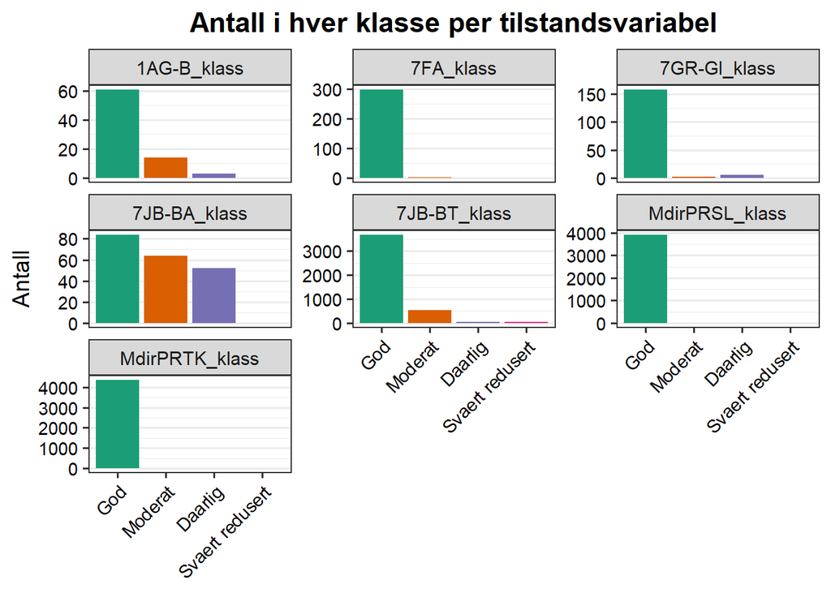

```r
quality_levels <- c("God", "Moderat", "Daarlig", "Svaert redusert")
plot_colors <- c("God"             = "#1b9e77",
                  "Moderat"         = "#d95f02",
                  "Daarlig"         = "#7570b3",
                  "Svaert redusert" = "#e7298a")

ANO.geo5 %>%
  st_drop_geometry() %>%
  select(all_of(vars)) %>%
  pivot_longer(cols = everything(),
               names_to = "Variable",
               values_to = "Kvalitet") %>%
  filter(!is.na(Kvalitet)) %>%
  mutate(Kvalitet = factor(Kvalitet, levels = quality_levels, ordered = TRUE)) %>%
      ggplot(aes(x = Kvalitet, fill = Kvalitet)) +
      geom_bar() +
      scale_fill_manual(values = plot_colors, name = "Klasse") +
      facet_wrap(~ Variable, scales = "free_y") +
      theme_bw(base_size = 14) +
      labs(title = "Antall i hver klasse per tilstandsvariabel",
            x = "Kvalitet",  y = "Antall") +
      theme(plot.title = element_text(hjust = 0.5, face = "bold"),
            axis.text.x = element_text(size = 11, colour = "black",  angle = 45, hjust = 1),
            axis.text.y = element_text(size = 11, colour = "black"),
            panel.grid.major.x = element_blank(),
            axis.title.x = element_blank(),
             legend.position = "none")
```

## Assign final tilstands classification based on the variables

The worst level will decide the final tilstand (Svaert redusert < Daarlig < Moderat < God)

```r
klass_vars <- c("1AG-B_klass", "7FA_klass", "7GR-GI_klass",
                "7JB-BA_klass", "7JB-BT_klass", "MdirPRSL_klass",  "MdirPRTK_klass")

quality_levels = c("Svaert redusert", "Daarlig", "Moderat", "God")

ANO.geo5 <- ANO.geo5 %>%
              mutate(across(all_of(klass_vars),
                  ~ factor(.x, levels = quality_levels, ordered = TRUE))) %>%
              rowwise() %>%
              mutate(Classification = {
                  vals <- c_across(all_of(klass_vars))
                  if (all(is.na(vals))) {
                    NA_character_
                  } else {
                    as.character(min(vals, na.rm = TRUE))
                  }
                }) %>%
              ungroup() %>%
              relocate(Classification, .after = 'MdirPRTK_klass')

ANO.geo5 %>%
  st_drop_geometry() %>%
  count(Classification) %>%
  arrange(desc(n))
```

```
# A tibble: 5 × 2
  Classification      n
  <chr>           <int>
1 God              4355
2 Moderat           640
3 Daarlig            98
4 Svaert redusert    54
5 <NA>               52
```

```r
ANO.geo5 %>%
  st_drop_geometry() %>%
  count(ntyp_final) %>%
  arrange(desc(n)) %>%
  print(n=63)
```

```
# A tibble: 63 × 2
   ntyp_final     n
   <chr>      <int>
 1 B3.1        2919
 2 B4.1         493
 3 D1           380
 4 B5.1         200
 5 B3.2         175
 6 B4.2          95
 7 D2.2          95
 8 D2            91
 9 C12.2         85
10 D4            83
11 E12           74
12 C12.1         65
```

[output cut: 51 more lines]

```r
# for some of the nature types the right variables have not been registered to be able to use
# this classification.

plot_colors <- c("God"             = "#1b9e77",
                 "Moderat"         = "#d95f02",
                 "Daarlig"         = "#7570b3",
                 "Svaert redusert" = "#e7298a",
                 "NA"              = "grey70")
nice_order  <- c("God", "Moderat", "Daarlig", "Svaert redusert", "NA")
stack_order <- rev(nice_order)

plot_data <- ANO.geo5 %>%
              st_drop_geometry() %>%
              group_by(ntyp_final) %>%
              filter(n() > 10) %>%
              ungroup() %>%
              mutate(Classification = fct_explicit_na(Classification, na_level = "NA"),
                     Classification = factor(Classification, levels = stack_order)) %>%
              count(ntyp_final, Classification) %>%
              group_by(ntyp_final) %>%
              mutate(total_n = sum(n)) %>%
              ungroup() %>%
              mutate(ntyp_final = fct_reorder(ntyp_final, total_n))
```

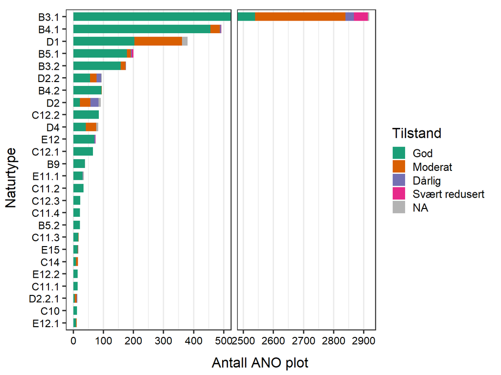

```r
p1<- ggplot(plot_data, aes(x = ntyp_final, y = n, fill = Classification)) +
          geom_col(width = 0.7) +
          scale_y_break(c(500, 2500), expand = c(0.05, 0)) +
          coord_flip() +
          scale_fill_manual(values = plot_colors,
                            breaks = nice_order,
                            name = "Tilstand",
                            labels = c("God" = "God",
                                       "Moderat" = "Moderat",
                                        "Daarlig" = "Dårlig",
                                        "Svaert redusert" = "Svært redusert",
                                       "NA" = "NA")) +
          labs( x = "Naturtype",
                y = "Antall ANO plot") +
          theme_bw(base_size = 16) +
          theme(plot.title = element_text(hjust = 0.5, face = "bold"),
                legend.key.size = unit(0.55, "cm"),
                axis.text = element_text(size = 12, colour = "black"),
                panel.grid.major.y = element_blank())
p1
```

```r
ggsave(filename = "barplot.jpeg",
       plot = p1,
       width = 9,
       height = 7.5,
       units = "in",
       device = "jpeg",
       dpi = 600)
```

Trying to compare species abundance in the dårlig and god classification only makes sense for D2 (seminaturlig eng) and B3.1 as this is the only naturetype with enough ANO circles in both conditions.

# Why are so many ANO circles in good condition?

It is related to what variables we use to evaluate on and how many of them are included in the ANO dataset.Many of the nature types have very few of there evaluation variables represented in the ANO data

```r
# raw variable names (without _klass)
naturclass_filtered <- naturclass %>%
                          mutate(Variabel2 = str_extract(Variabel, "(?<=\\().+?(?=\\))")) %>%
                          relocate(Variabel2, .after = Variabel)

valid_vars <- c("7GR-GI", "7JB-SI", "7JB-BA", "7JB-BT",
                "MdirPRSL", "MdirPRTK", "1AG-B", "7FA")

# which variables are normally used to create the classification
expected_vars <- naturclass_filtered %>%
                      filter(!is.na(Variabel2)) %>%
                      mutate(Variabel2 = str_trim(Variabel2)) %>%
                      distinct(Naturtype_kode, Variabel2) %>%
                      rename(ntyp_clean = Naturtype_kode) %>%
                      mutate(has_column = Variabel2 %in% names(ANO.geo5))  # mark whether this variable exists as a column in ANO.geo5

# variables that are real columns
present_vars <- expected_vars %>%
                    filter(has_column) %>%
                    distinct(Variabel2) %>%
                    pull()


# naturtypes that actually occur in the data
present_types <- ANO.geo5 %>%
  distinct(ntyp_clean)

all_cols <- names(ANO.geo5)

# 1) All variables used in the lookup (for types that exist in ANO.geo5)
vars_per_type <- naturclass_filtered %>%
                      filter(!is.na(Variabel2)) %>%
                      mutate(Variabel2 = str_trim(Variabel2)) %>%
                      semi_join(present_types, by = c("Naturtype_kode" = "ntyp_clean")) %>%
                      distinct(Naturtype_kode, Variabel2) %>%
                      rename(ntyp_clean = Naturtype_kode) %>%
                      mutate(has_column = Variabel2 %in% all_cols)

# 2) Long version of ANO.geo5 for the variables that *do* exist as columns
raw_vars <- vars_per_type %>%
                filter(has_column) %>%
                pull(Variabel2) %>%
                unique()

ANO_long <- ANO.geo5 %>%
              st_drop_geometry() %>%
              mutate(across(all_of(raw_vars), as.character)) %>%
              select(ntyp_clean, all_of(raw_vars)) %>%
              pivot_longer(cols = all_of(raw_vars),
                            names_to  = "Variabel2",
                            values_to = "Value")

# 3) Combine + summarise in one go
per_type <- vars_per_type %>%
                  left_join(ANO_long, by = c("ntyp_clean", "Variabel2")) %>%
                  group_by(ntyp_clean, Variabel2) %>%
                  summarise(has_column = first(has_column),
                            has_data   = has_column && any(!is.na(Value)),
                            .groups = "drop") %>%
                  group_by(ntyp_clean) %>%
                  summarise('primary variables from mdir'    = n(),          # from lookup
                            'variables in ANO data' = sum(has_column),      # exist as columns
                            'variables that has data'   = sum(has_data),        # have any non-NA value
                            .groups = "drop") %>%
                  arrange(ntyp_clean)

per_type
```

```
# A tibble: 64 × 4
   ntyp_clean `primary variables from mdir` `variables in ANO data`
   <chr>                              <int>                   <int>
 1 A1                                     2                       2
 2 A10                                    3                       3
 3 A5                                     3                       3
 4 A7                                     1                       0
 5 A8                                     5                       4
 6 B3.1                                   4                       3
 7 B3.2                                   4                       3
 8 B4.1                                   4                       3
 9 B4.2                                   4                       3
10 B5.1                                   4                       3
# ℹ 54 more rows
# ℹ 1 more variable: `variables that has data` <int>
```

```r
summary_stats <- per_type %>%
  summarise(
    n_naturtyper = n(),
    total_primary = sum(`primary variables from mdir`, na.rm = TRUE),
    total_in_ano = sum(`variables in ANO data`, na.rm = TRUE),
    total_with_data = sum(`variables that has data`, na.rm = TRUE),
    naturtyper_med_fullt_sett = sum(`primary variables from mdir` == `variables in ANO data`),
    naturtyper_med_delvis = sum(`variables in ANO data` > 0 & `variables in ANO data` < `primary variables from mdir`),
    naturtyper_uten_variabler = sum(`variables in ANO data` == 0),
    naturtyper_uten_data = sum(`variables that has data` == 0)
  )

summary_stats
```

```
# A tibble: 1 × 8
  n_naturtyper total_primary total_in_ano total_with_data naturtyper_med_fullt…¹
         <int>         <int>        <int>           <int>                  <int>
1           64           212          140             126                     21
# ℹ abbreviated name: ¹naturtyper_med_fullt_sett
# ℹ 3 more variables: naturtyper_med_delvis <int>,
#   naturtyper_uten_variabler <int>, naturtyper_uten_data <int>
```

# Ordination

For most nature types, the number of ANO plots classified as ‘Dårlig’ or ‘Svært redusert’ is too low to allow a meaningful comparison of species composition between condition classes. As a result, ordination analyses were restricted to nature types with sufficient sample size in both ‘God’ and ‘Dårlig’ condition classes.

**B3.1**

```r
ANO.ordB3 <- ANO.geo5 %>%
                filter(ntyp_clean == "B3.1",
                       Classification %in% c("God", "Daarlig", "Svaert redusert"))
table(ANO.ordB3$Classification)

## 1. Join: attach ANO.geo metadata to each ANO.sp subplot
##    (keep only subplots that actually have a parent)
ANO_linkedB3 <- ANO.sp %>%
  inner_join(ANO.ordB3, by = c("parentglobalid" = "globalid"))
# After this:
# - globalid        = ID of the ANO.sp subplot  (site)
# - parentglobalid  = ID of the ANO.geo plot (parent)
# - + all metadata from ANO.geo
table(ANO_linkedB3$parentglobalid)

bad_plot <- c("{6B40A690-24D3-4BAF-9FBC-3CCCF467F46F}", "{A102AC14-3760-41C7-9043-320E42FABE18}", "{C0772BDC-000B-49AF-9730-6AD8C42575F4}")
ANO_linkedB3 <- ANO_linkedB3 %>%
                filter(parentglobalid != bad_plot)

## 2. Make wide species matrix aggregated at the 250m
ANO_parent_wideB3 <- ANO_linkedB3 %>%
                        group_by(parentglobalid,
                                 hovedoekosystem_250m2,
                                 kartleggingsenhet_1m2,
                                 hovedtype_1m2,
                                 ntyp_clean,
                                 Classification,
                                 art_navn) %>%
                        summarise(art_dekning = max(art_dekning), .groups = "drop") %>%
                        pivot_wider(id_cols = c(parentglobalid,
                                                hovedoekosystem_250m2,
                                                kartleggingsenhet_1m2,
                                                hovedtype_1m2,
                                                ntyp_clean,
                                                Classification),
                                    names_from  = art_navn,
                                    values_from = art_dekning,
                                    values_fill = 0) %>%
                        rename(site_id = parentglobalid)

## 3. Split into species matrix and environment data for vegan
sp_matB3 <- ANO_parent_wideB3 %>%
            select(-hovedoekosystem_250m2,
                   -kartleggingsenhet_1m2,
                   -hovedtype_1m2,
                   -ntyp_clean,
                   -Classification) %>%
            column_to_rownames("site_id") %>%
            as.matrix()

sp_matB3[is.na(sp_matB3)] <- 0
sp_matB3 <- sp_matB3[rowSums(sp_matB3) > 0, ]
sp_matB3 <- sp_matB3[, colSums(sp_matB3) > 0]

which(rowSums(sp_matB3) == 0)
which(colSums(sp_matB3) == 0)

envB3 <- ANO_parent_wideB3 %>%
            select(site_id,
                   hovedoekosystem_250m2,
                   kartleggingsenhet_1m2,
                   hovedtype_1m2,
                   ntyp_clean,
                   Classification) %>%
            distinct(site_id, .keep_all = TRUE) %>%
            column_to_rownames("site_id")
envB3 <- envB3[rownames(sp_matB3), ]

bad_sites <- c("{6B40A690-24D3-4BAF-9FBC-3CCCF467F46F}", "{A102AC14-3760-41C7-9043-320E42FABE18}", "{C0772BDC-000B-49AF-9730-6AD8C42575F4}")
  # Extreme outliers

sp_mat_fB3 <- sp_matB3[!rownames(sp_matB3) %in% bad_sites, ]
env_fB3    <- envB3[!rownames(envB3) %in% bad_sites, ]
```

**D2**

```r
ANO.ordD2 <- ANO.geo5 %>%
              filter(ntyp_clean == "D2",
                     Classification %in% c("God", "Daarlig"))

## 1. Join: attach ANO.geo metadata to each ANO.sp subplot
##    (keep only subplots that actually have a parent)
ANO_linkedD2 <- ANO.sp %>%
  inner_join(ANO.ordD2, by = c("parentglobalid" = "globalid"))
table(ANO.ordD2$Classification)
# After this:
# - globalid        = ID of the ANO.sp subplot  (site)
# - parentglobalid  = ID of the ANO.geo plot (parent)
# - + all metadata from ANO.geo
table(ANO_linkedD2$parentglobalid)

## 2. Make wide species matrix with site = ANO.sp globalid
ANO_parent_wideD2 <- ANO_linkedD2 %>%
                        group_by(parentglobalid,
                                 hovedoekosystem_250m2,
                                 kartleggingsenhet_1m2,
                                 hovedtype_1m2,
                                 ntyp_clean,
                                 Classification,
                                 art_navn) %>%
                        pivot_wider(id_cols = c(parentglobalid,
                                                hovedoekosystem_250m2,
                                                kartleggingsenhet_1m2,
                                                hovedtype_1m2,
                                                ntyp_clean,
                                                Classification),
                                    names_from  = art_navn,
                                    values_from = art_dekning,
                                    values_fill = 0) %>%
                        rename(site_id = parentglobalid) %>%
                        ungroup()

## 3. Split into species matrix and environment data for vegan
sp_matD2 <- ANO_parent_wideD2 %>%
                select(-hovedoekosystem_250m2,
                       -kartleggingsenhet_1m2,
                       -hovedtype_1m2,
                       -ntyp_clean,
                       -Classification) %>%
                column_to_rownames("site_id") %>%
                as.matrix()

sp_matD2[is.na(sp_matD2)] <- 0
sp_matD2 <- sp_matD2[rowSums(sp_matD2) > 0, ]
sp_matD2 <- sp_matD2[, colSums(sp_matD2) > 0]

which(rowSums(sp_matD2) == 0)
which(colSums(sp_matD2) == 0)


envD2 <- ANO_parent_wideD2 %>%
              select(site_id,
                     hovedoekosystem_250m2,
                     kartleggingsenhet_1m2,
                     hovedtype_1m2,
                     ntyp_clean,
                     Classification) %>%
              distinct(site_id, .keep_all = TRUE) %>%
              column_to_rownames("site_id")

envD2 <- envD2[rownames(sp_matD2), ]
```

## Ordination

**B3.1**

```r
#set.seed(123)
#ord.B3 <- metaMDS(sp_mat_fB3, k =3, distance = "bray", trymax = 200)
#saveRDS(ord.B3, "ord.B3.rds")
ord.B3 <- readRDS("C:/Users/mie.arnberg/OneDrive - NINA/ANO/ord.B3.rds")

env_fitB3 <- env_fB3 %>%
            select(Classification) %>%
            mutate( Classification = as.factor(Classification))

set.seed(123)
fitB3 <- envfit(ord.B3, env_fitB3, permutations = 999)
```

```r
ord.B3$stress
```

```
[1] 0.1915749
```

```r
fitB3
```

```
***FACTORS:

Centroids:
                                NMDS1   NMDS2
ClassificationDaarlig         -0.2888  0.2523
ClassificationGod              0.0086 -0.0084
ClassificationSvaert redusert -0.2994  0.3056

Goodness of fit:
                   r2 Pr(>r)
Classification 0.0104  0.001 ***
---
Signif. codes:  0 '***' 0.001 '**' 0.01 '*' 0.05 '.' 0.1 ' ' 1
Permutation: free
Number of permutations: 999
```

**D2**

```r
# with different transofrmations
set.seed(123)
ord.D2 <- metaMDS(sp_matD2, distance = "bray", trymax = 200)

env_fitD2 <- envD2 %>%
            select(Classification) %>%
            mutate( Classification = as.factor(Classification))

set.seed(123)
fitD2 <- envfit(ord.D2, env_fitD2, permutations = 999)
```

```r
ord.D2$stress
```

```
[1] 0.2569586
```

```r
fitD2
```

```
***FACTORS:

Centroids:
                        NMDS1   NMDS2
ClassificationDaarlig  0.0585 -0.0441
ClassificationGod     -0.0719  0.0541

Goodness of fit:
                   r2 Pr(>r)
Classification 0.0181  0.398
Permutation: free
Number of permutations: 999
```

**Make a ordination plot**

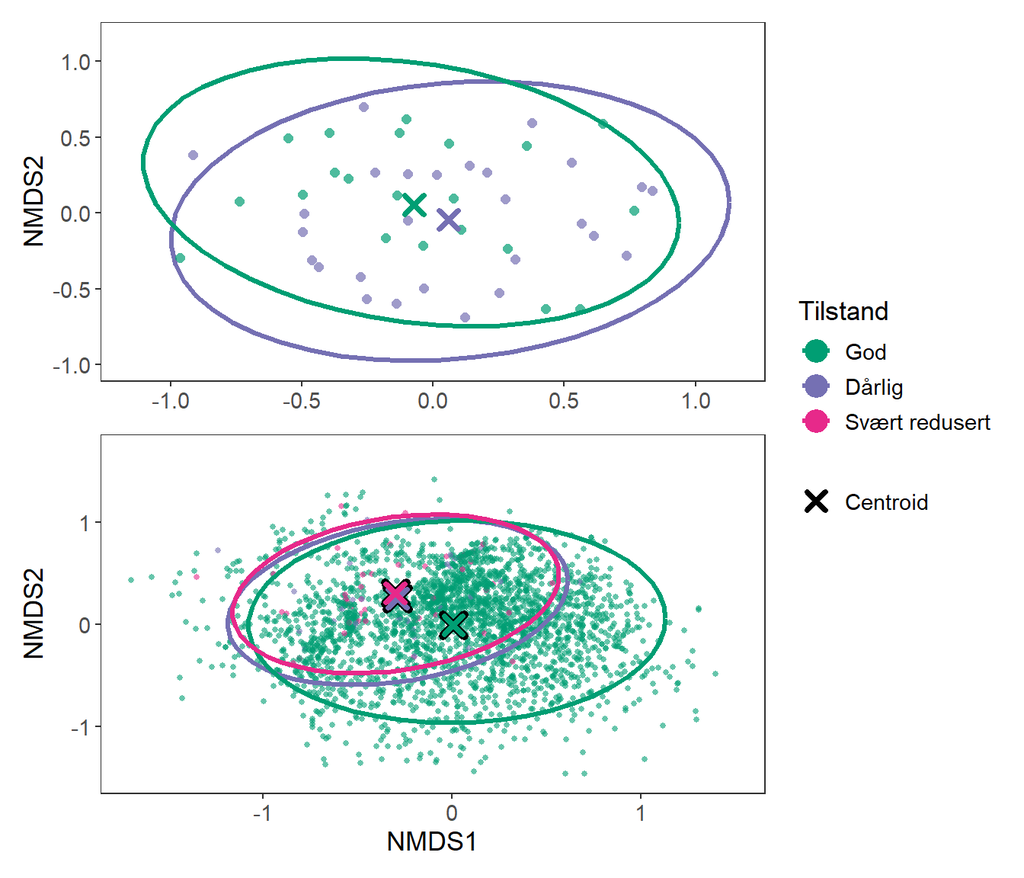

```r
nmds_sitesD2 <- as.data.frame(scores(ord.D2, display = "sites"))
nmds_sitesD2$site_id <- rownames(nmds_sitesD2)
centroidsD2 <- as.data.frame(scores(fitD2, "factors"))
centroidsD2$Classification <- rownames(centroidsD2)
centroidsD2$Classification <- sub("^Classification", "", rownames(centroidsD2))

plotdataD2 <- nmds_sitesD2 %>%
               left_join(ANO_parent_wideD2, by = c("site_id" = "site_id"))

nice_order  <- c("God", "Daarlig")
pD2 <-ggplot(plotdataD2, aes(NMDS1, NMDS2, color = Classification)) +
                stat_ellipse(linewidth = 1.1) +
                geom_point(size = 2, alpha = 0.7, shape = 16) +
                geom_point(data = centroidsD2, aes(x = NMDS1, y = NMDS2, colour = Classification, shape = "Centroid"),
                           size = 3, stroke = 2) +
                scale_shape_manual(name = NULL, values = c("Centroid" = 4)) +
                scale_color_manual(values = c("God"     = "#009E73",
                                              "Daarlig" = "#7570b3"),
                                   breaks = nice_order,
                                   labels = c("God" = "God",
                                              "Daarlig" = "Dårlig"),
                                   name = "Tilstand") +
                theme_minimal() +
                labs(color = "Classification")+
                 xlim(-1.15, 1.15) + ylim(-1, 1.15) +
                theme_bw() +
                theme(panel.grid = element_blank(),
                        axis.title.y = element_text(size = 13),
                       axis.title.x = element_blank(),
                        axis.text = element_text(size = 11),
                        legend.text = element_text(size = 11))+
  guides(color = "none", shape = "none")


nmds_sitesB3 <- as.data.frame(scores(ord.B3, display = "sites"))
nmds_sitesB3$site_id <- rownames(nmds_sitesB3)
centroidsB3 <- as.data.frame(scores(fitB3, "factors"))
centroidsB3$Classification <- rownames(centroidsB3)
centroidsB3$Classification <- sub("^Classification", "", rownames(centroidsB3))

plotdataB3 <- nmds_sitesB3 %>%
               left_join(ANO_parent_wideB3, by = c("site_id" = "site_id"))

nice_order1  <- c("God", "Daarlig", "Svaert redusert")
pB3 <- ggplot(plotdataB3, aes(NMDS1, NMDS2, color = Classification)) +
                geom_point(size = 1, alpha = 0.6, shape = 16) +
                geom_point(data = centroidsB3, aes(NMDS1, NMDS2),
                            shape = 4, color = "black", size = 3, stroke = 3)  +
                geom_point(data = centroidsB3, aes(x = NMDS1, y = NMDS2, colour = Classification, shape = "Centroid"),
                           size = 3, stroke = 2) +
                scale_shape_manual(name = NULL, values = c("Centroid" = 4)) +
                scale_color_manual(values = c("God"     = "#009E73",
                                              "Daarlig" = "#7570b3",
                                              "Svaert redusert" = "#e7298a"),
                                   breaks = nice_order1,
                                   labels = c("God" = "God",
                                              "Daarlig" = "Dårlig",
                                              "Svaert redusert" = "Svært redusert"),
                                   name = "Tilstand") +
                stat_ellipse(linewidth = 1.1) +
                theme_minimal() +
                labs(color = "Classification")+
                xlim(-1.7, 1.5) + ylim(-1.5, 1.7) +
                theme_bw() +
                theme(panel.grid = element_blank(),
                        axis.title = element_text(size = 13),
                        axis.text = element_text(size = 11),
                        legend.title = element_text(size = 13),
                        legend.text = element_text(size = 11))


p2<- (pD2 / pB3) +
  plot_layout(heights = c(1, 1), guides = "collect") &
  theme(legend.position = "right")
p2
```

```r
ggsave(filename = "ordination.jpeg",
       plot = p2,
       width = 7,
       height = 6.5,
       units = "in",
       device = "jpeg",
       dpi = 600)
```

# Species lists

We will make species lists with mean abundance for the different conditions within each nature type.

```r
ANO_linked_all <- ANO.sp %>%
                    inner_join(ANO.geo5, by = c("parentglobalid" = "globalid"))

species_summary <- ANO_linked_all %>%
                      filter(Classification %in% c("God", "Moderat", "Daarlig", "Svaert redusert")) %>%
                      group_by(ntyp_final, Classification) %>%
                      mutate(total_plots = n_distinct(parentglobalid)) %>%
                      ungroup() %>%
                      group_by(ntyp_final, Classification, art_navn) %>%
                      summarise(total_plots     = first(total_plots),
                                n_plots_species = n_distinct(parentglobalid),
                                perc_plots      = 100 * n_plots_species / total_plots,
                                median_cover_present = median(art_dekning, na.rm = TRUE),
                                mean_cover_all = sum(art_dekning, na.rm = TRUE) / total_plots,
                                max_cover = suppressWarnings(max(art_dekning, na.rm = TRUE)),
                                min_cover_obs = suppressWarnings(min(art_dekning, na.rm = TRUE)),
                                .groups = "drop" ) %>%
                      mutate(min_cover = ifelse(n_plots_species < total_plots, 0, min_cover_obs),
                             range_cover = paste0(min_cover, "–", max_cover)) %>%
                      select(-min_cover_obs) %>%
                      arrange(ntyp_final, Classification, desc(perc_plots), art_navn)

species_summary
```

```
# A tibble: 4,806 × 11
   ntyp_final Classification art_navn     total_plots n_plots_species perc_plots
   <chr>      <chr>          <chr>              <int>           <int>      <dbl>
 1 A1         God            poa alpina             1               1        100
 2 A1         God            saxifraga o…           1               1        100
 3 A1         God            silene acau…           1               1        100
 4 A10        God            arctous alp…           1               1        100
 5 A10        God            empetrum ni…           1               1        100
 6 A10        God            vaccinium u…           1               1        100
 7 A10        God            vaccinium v…           1               1        100
 8 A5         God            agrostis ca…           4               2         50
 9 A5         God            atriplex li…           4               1         25
10 A5         God            avenella fl…           4               1         25
# ℹ 4,796 more rows
# ℹ 5 more variables: median_cover_present <dbl>, mean_cover_all <dbl>,
#   max_cover <dbl>, min_cover <dbl>, range_cover <chr>
```

```r
species_summary_nice <- species_summary %>%
                            mutate(perc_plots           = round(perc_plots, 2),
                                   mean_cover_all       = round(mean_cover_all, 2),
                                   median_cover_present = round(median_cover_present, 2),
                                   max_cover            = round(max_cover, 0),
                                   min_cover            = round(min_cover, 0),
                                   perc_str   = format(perc_plots,
                                                      decimal.mark = ",", big.mark = "", trim = TRUE),
                                   mean_str   = format(mean_cover_all,
                                                      decimal.mark = ",", big.mark = "", trim = TRUE),
                                   median_str = format(median_cover_present,
                                                      decimal.mark = ",", big.mark = "", trim = TRUE),
                                   min_str    = format(min_cover,
                                                      decimal.mark = ",", big.mark = "", trim = TRUE),
                                   max_str    = format(max_cover,
                                                      decimal.mark = ",", big.mark = "", trim = TRUE),
                                   mean_with_range = paste0(mean_str, " (", min_str, "–", max_str, ")"))


make_table_for_naturtype <- function(ntype,
                                     data = species_summary_nice) {

  data %>%
    filter(ntyp_final == ntype) %>%
    arrange(factor(Classification,
                    levels = c("God", "Moderat", "Daarlig", "Svaert redusert")),
            desc(perc_plots),
            desc(mean_cover_all),
            art_navn) %>%
    mutate(art_cap = str_to_sentence(art_navn),
          Tilstand = recode(Classification,
                            "Daarlig" = "Dårlig",
                            "Svaert redusert" = "Svært redusert",
                            .default = Classification)) %>%
    select( `Art`                               = art_cap,
            `Tilstand`                          = Tilstand,
            `Antall plott`                      = n_plots_species,
            `% plott`                           = perc_str,
            `Middel dekning over alle plott (range)` = mean_with_range,
            `Median dekning i plot der arten finnes` = median_str )
}


B3.1<- make_table_for_naturtype("B3.1")


# make the plot number fan
plot_oversikt <- ANO.geo5 %>%
                    filter(Classification %in% c("God", "Moderat", "Daarlig", "Svaert redusert")) %>%
                    distinct(ntyp_final, Classification, globalid) %>%  # unike plott per naturtype/tilstand
                    count(ntyp_final, Classification, name = "n_plots") %>%
                    tidyr::pivot_wider(names_from  = Classification,
                      values_from = n_plots,
                      values_fill = 0) %>%
                    rename( `Naturtype`      = ntyp_final,
                            `God`            = God,
                            `Moderat`        = Moderat,
                            `Dårlig`         = Daarlig,
                            `Svært redusert` = `Svaert redusert`) %>%
                    mutate(`Totalt antall plott` = God + Moderat + `Dårlig` + `Svært redusert`) %>%
                    arrange(Naturtype)

# Make excle file
naturtyper <- sort(unique(species_summary_nice$ntyp_final))

tabs_for_excel <- lapply(naturtyper, function(nt) {
  make_table_for_naturtype(nt)
})

names(tabs_for_excel) <- naturtyper

tabs_for_excel <- c(list("Plot_oversikt" = plot_oversikt),
                    tabs_for_excel)

write_xlsx(tabs_for_excel, path = "Artslister_per_naturtype_rapport.xlsx")
```

Make a slimmed down list for the report main text.

```r
make_table_for_naturtype <- function(ntype,
                                     min_perc = 10,
                                     data = species_summary_nice) {

  # keep only desired condition classes
  data_nt <- data %>%
    filter(ntyp_final == ntype,
      Classification %in% c("God", "Daarlig", "Svaert redusert"))

  # species selection: ≥10 % in at least one condition
  species_keep <- data_nt %>%
    group_by(art_navn) %>%
    summarise(max_perc = max(perc_plots, na.rm = TRUE),
      .groups = "drop") %>%
    filter(max_perc >= min_perc) %>%
    pull(art_navn)

  # final table
  data_nt %>%
    filter(art_navn %in% species_keep) %>%
    arrange(factor(Classification,
             levels = c("God", "Daarlig", "Svaert redusert")),
            desc(perc_plots),
            desc(mean_cover_all),
            art_navn) %>%
    mutate(Art = str_to_sentence(art_navn),
           Tilstand = recode(Classification,
                             "Daarlig" = "Dårlig",
                              "Svaert redusert" = "Svært redusert")) %>%
    select(Art,
            Tilstand,
            `Antall plott` = n_plots_species,
            `% plott` = perc_str,
            `Middel dekning over alle plott (range)` = mean_with_range,
            `Median dekning i plott der arten finnes` = median_str)}

B3.1 <- make_table_for_naturtype("B3.1", min_perc = 10)


naturtyper <- sort(unique(species_summary_nice$ntyp_final))

tabs_for_excel <- lapply(naturtyper, function(nt) {
  make_table_for_naturtype(nt, min_perc = 10)
})

names(tabs_for_excel) <- naturtyper

write_xlsx(tabs_for_excel,
           path = "Artslister_per_naturtype_God_Darlig_SvaertRedusert1.xlsx")
```